# Predicting House Prices

# Data Description and exploration

Variable——Description

s_p———–Sale price in dollar  
inv———–Sale date inventory of homes on market  
bath———-Number of bathrooms  
ltsz———-Lot size in acres  
hssz———-Sq. ft. of living area  
bsemt———1 if basement, 0 otherwise  
a_c———–1 if central a/c, 0 otherwise  
f_place——-1 if fireplace, 0 otherwise  
garsz_a——-1 if garage, 0 otherwise  
dinsp———1 if dining space, 0 otherwise  
dw————1 if dishwasher, 0 otherwise  
dr————1 if dining room, 0 otherwise  
fr————1 if family room, 0 otherwise  
age5———-1 if age <= 5 yrs, 0 otherwise  
stl10———1 if 1 story house, 0 otherwise  
bdrms———Number of bedrooms

I start off with data exploration and some transformation. Afterwards, we will look into two types of modelling: explanatory and predictive. Whereas the goal of explanatory analysis is to define which variables are most important to explain variance of the dependent variables (r-squared), the predictive model solely focuses on low prediction (RMSE as performance indicator for example) errors.

```r
#setting working directory and listing files in that directory

rm(list = ls(all = TRUE))
getwd()
```

```
## [1] "D:/Github/sites/datasciencephil.github.io/projects"
```

```r
setwd("D:/Github/sites/datasciencephil.github.io/projects")

#list.files()
```

```r
# reading the file and looking at summary statistics

require(readxl)
require(psych)
set.seed(1)

dt = read_excel("housedata for final 2018.xlsx" )
summary(dt)
```

```
##       s_p              inv             bath             ltsz
##  Min.   : 29864   Min.   : 61.0   Min.   : 1.000   Min.   :0.01561
##  1st Qu.: 59278   1st Qu.:101.0   1st Qu.: 1.500   1st Qu.:0.17880
##  Median : 70360   Median :135.0   Median : 2.000   Median :0.22495
##  Mean   : 79037   Mean   :140.8   Mean   : 1.948   Mean   :0.33333
##  3rd Qu.: 90741   3rd Qu.:154.0   3rd Qu.: 2.500   3rd Qu.:0.27548
##  Max.   :222680   Max.   :322.0   Max.   :20.000   Max.   :4.13223
##       hssz          bsemt             a_c            f_place
##  Min.   : 216   Min.   :0.0000   Min.   :0.0000   Min.   :0.0000
##  1st Qu.: 875   1st Qu.:1.0000   1st Qu.:1.0000   1st Qu.:0.0000
##  Median :1014   Median :1.0000   Median :1.0000   Median :1.0000
##  Mean   :1055   Mean   :0.9368   Mean   :0.8137   Mean   :0.5968
##  3rd Qu.:1199   3rd Qu.:1.0000   3rd Qu.:1.0000   3rd Qu.:1.0000
##  Max.   :3080   Max.   :1.0000   Max.   :1.0000   Max.   :1.0000
##     garsz_a             dw               dr               fr
##  Min.   :0.0000   Min.   :0.0000   Min.   :0.0000   Min.   :0.0000
##  1st Qu.:1.0000   1st Qu.:1.0000   1st Qu.:1.0000   1st Qu.:1.0000
##  Median :1.0000   Median :1.0000   Median :1.0000   Median :1.0000
##  Mean   :0.9611   Mean   :0.8063   Mean   :0.7589   Mean   :0.7821
##  3rd Qu.:1.0000   3rd Qu.:1.0000   3rd Qu.:1.0000   3rd Qu.:1.0000
##  Max.   :2.0000   Max.   :1.0000   Max.   :1.0000   Max.   :1.0000
##       age5            stl10            bdrms
##  Min.   :0.0000   Min.   :0.0000   Min.   :-4.000
##  1st Qu.:0.0000   1st Qu.:0.0000   1st Qu.: 3.000
##  Median :0.0000   Median :0.0000   Median : 3.000
##  Mean   :0.1537   Mean   :0.4737   Mean   : 3.276
##  3rd Qu.:0.0000   3rd Qu.:1.0000   3rd Qu.: 4.000
##  Max.   :1.0000   Max.   :1.0000   Max.   : 6.000
```

```r
describe(dt)
```

```
##         vars   n     mean       sd   median  trimmed      mad      min
## s_p        1 950 79037.11 29169.78 70360.00 74918.59 20115.92 29864.00
## inv        2 950   140.82    53.28   135.00   133.24    45.96    61.00
## bath       3 950     1.95     0.87     2.00     1.89     0.74     1.00
## ltsz       4 950     0.33     0.43     0.22     0.24     0.07     0.02
## hssz       5 950  1055.49   296.61  1014.00  1034.73   222.39   216.00
## bsemt      6 950     0.94     0.24     1.00     1.00     0.00     0.00
## a_c        7 950     0.81     0.39     1.00     0.89     0.00     0.00
## f_place    8 950     0.60     0.49     1.00     0.62     0.00     0.00
## garsz_a    9 950     0.96     0.20     1.00     1.00     0.00     0.00
## dw        10 950     0.81     0.40     1.00     0.88     0.00     0.00
## dr        11 950     0.76     0.43     1.00     0.82     0.00     0.00
## fr        12 950     0.78     0.41     1.00     0.85     0.00     0.00
## age5      13 950     0.15     0.36     0.00     0.07     0.00     0.00
## stl10     14 950     0.47     0.50     0.00     0.47     0.00     0.00
## bdrms     15 950     3.28     0.72     3.00     3.25     0.00    -4.00
##               max     range  skew kurtosis     se
## s_p     222680.00 192816.00  1.71     4.05 946.39
## inv        322.00    261.00  1.24     1.20   1.73
## bath        20.00     19.00  9.38   188.84   0.03
## ltsz         4.13      4.12  4.90    28.72   0.01
## hssz      3080.00   2864.00  1.36     5.36   9.62
## bsemt        1.00      1.00 -3.59    10.87   0.01
## a_c          1.00      1.00 -1.61     0.59   0.01
## f_place      1.00      1.00 -0.39    -1.85   0.02
## garsz_a      2.00      2.00 -4.35    19.57   0.01
## dw           1.00      1.00 -1.55     0.40   0.01
## dr           1.00      1.00 -1.21    -0.54   0.01
## fr           1.00      1.00 -1.36    -0.14   0.01
## age5         1.00      1.00  1.92     1.68   0.01
## stl10        1.00      1.00  0.11    -1.99   0.02
## bdrms        6.00     10.00 -0.60    11.49   0.02
```

We can see there are some outliers. One has to distinguish between data that “just does not look right”, like 20 bathrooms or a very high house price, but it is possible and a negative number of bedrooms, which is an obvious error. All the numbers in the dataset have to be positive, so we get rid of negative amounts of bedrooms. In addition, I will search the house with 20 bathrooms and change it to 2, as I think there was just an error and a 0 was added by accident.

### Data Prep (1): outliers

In this part we have a look at the data and potential outliers and how to treat these.

```r
# removal of outliers

require(readxl)
hd = read_excel("housedata for final 2018.xlsx" )

# acre to sqfeet
hd$ltsznew <- hd$ltsz*43560

# outlier treatment, alter to median
hd$hssz[hd$hssz > 2200 ] <- median(hd$hssz)
hd$ltsznew[hd$ltsznew > 500000 ] <- median(hd$ltsznew)
hd$garsz_a[hd$garsz_a > 1 ] <- median(hd$garsz_a)
hd$bdrms[hd$bdrms < 0 ] <- median(hd$bdrms)
hd$bath[hd$bath > 10 ] <- median(hd$bath)

# I looked at the ratio from hssz to ltsznew and 5 houses were bigger than the lot. I assumed thats a mistake as well and multiplied lots by 10
hd$ratio <- hd$hssz/hd$ltsznew
summary(hd$ratio)
```

```
##     Min.  1st Qu.   Median     Mean  3rd Qu.     Max.
## 0.005464 0.078689 0.107692 0.111196 0.131396 1.547619
```

```r
hd$ltsznew[hd$ratio >1] <- hd$ltsznew[hd$ratio>1]*10
hd$ratio[hd$ratio > 1]
```

```
## [1] 1.304348 1.142857 1.547619 1.200000 1.273469
```

```r
hd$ltsznew[hd$ratio>1]
```

```
## [1] 6900 8400 8400 6800 9800
```

```r
hd$hssz[hd$ratio>1]
```

```
## [1]  900  960 1300  816 1248
```

```r
# some sanity checks
mean(hd$hssz)
```

```
## [1] 1045.825
```

```r
mean(hd$ltsznew)
```

```
## [1] 14557.89
```

```r
median(hd$hssz)
```

```
## [1] 1014
```

```r
median(hd$ltsznew)
```

```
## [1] 9800
```

### Data Prep (2): Transformation

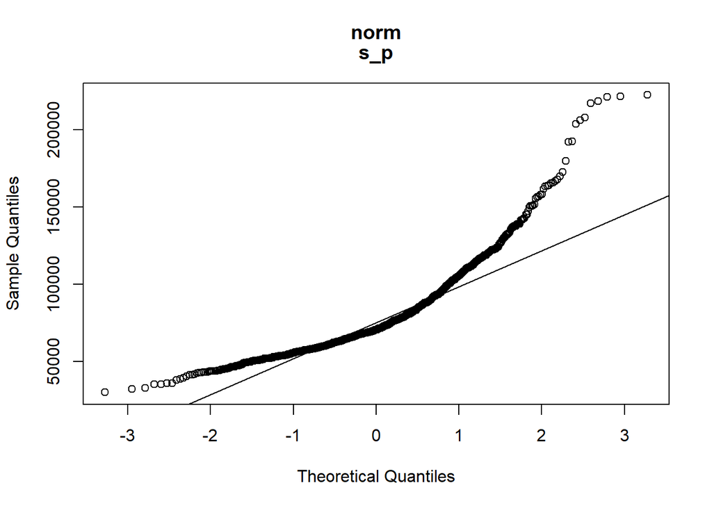

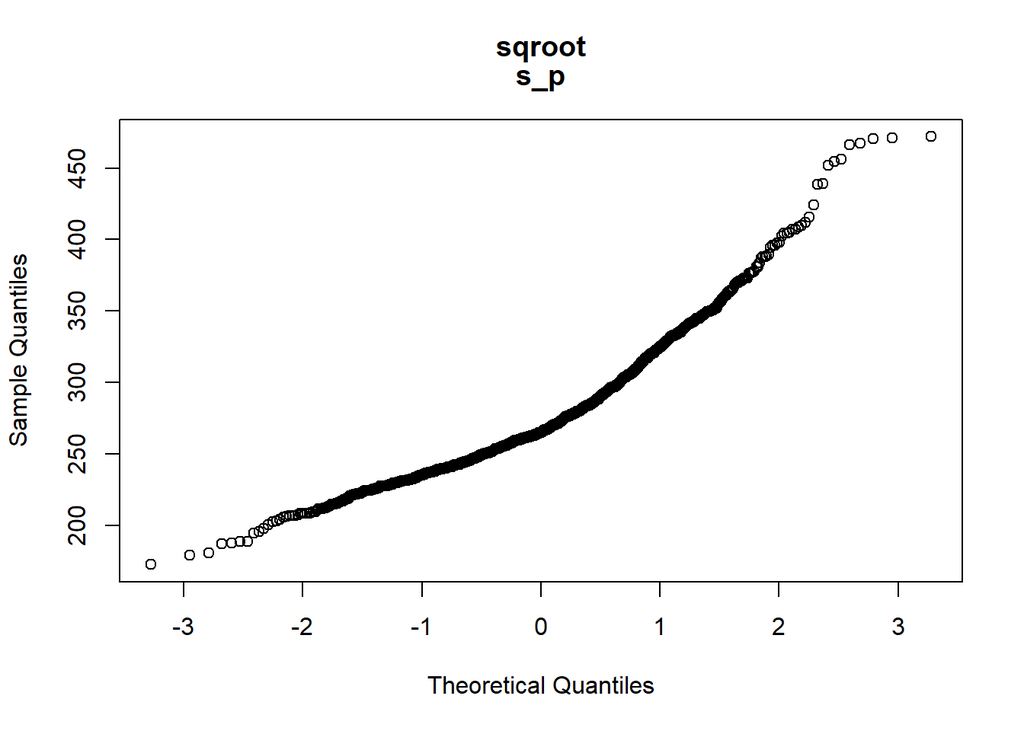

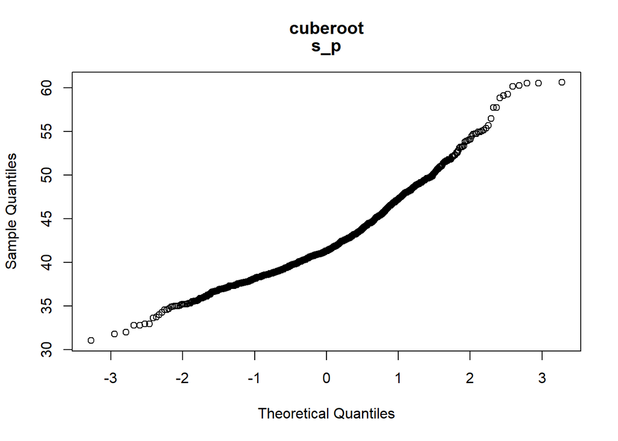

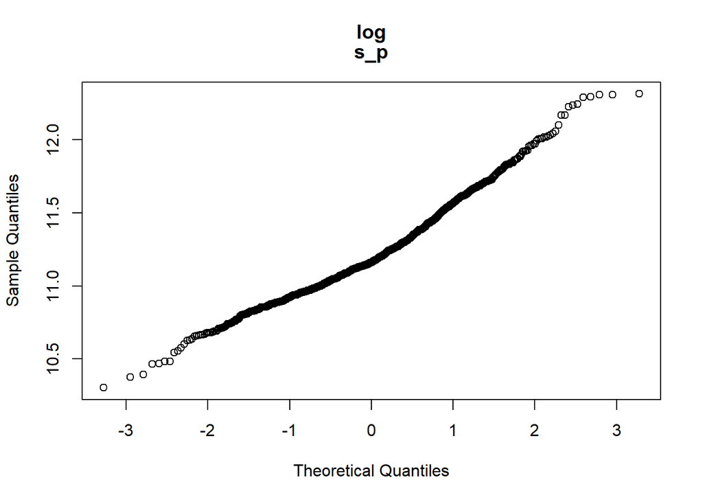

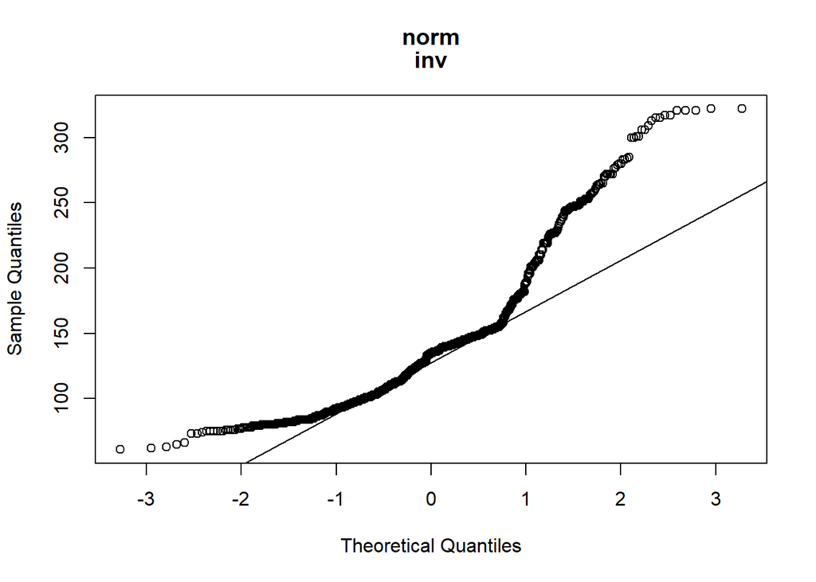

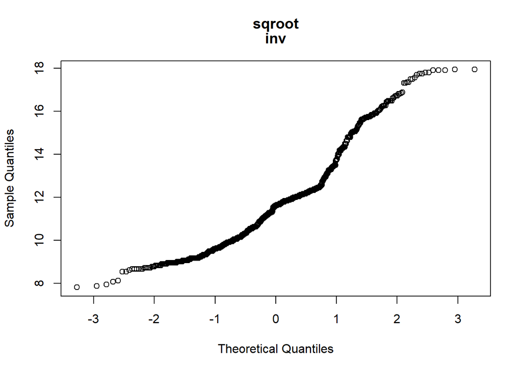

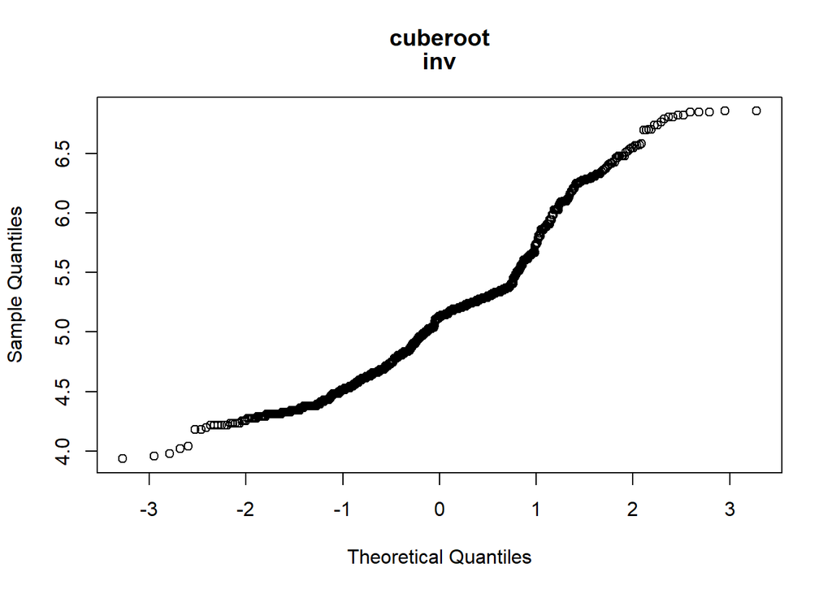

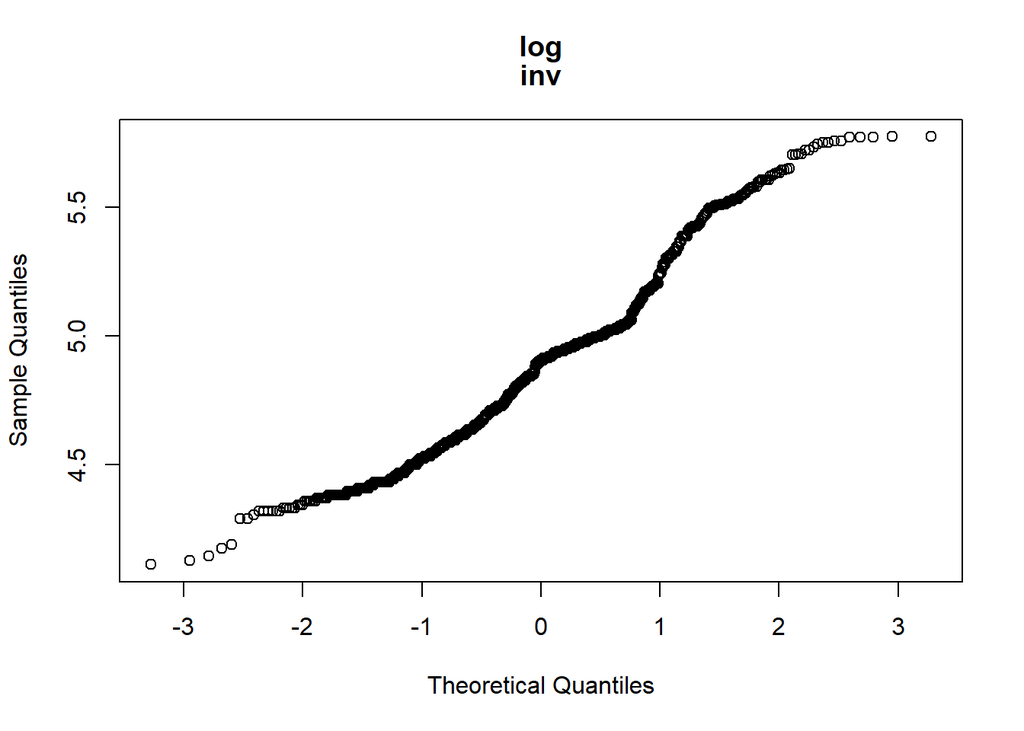

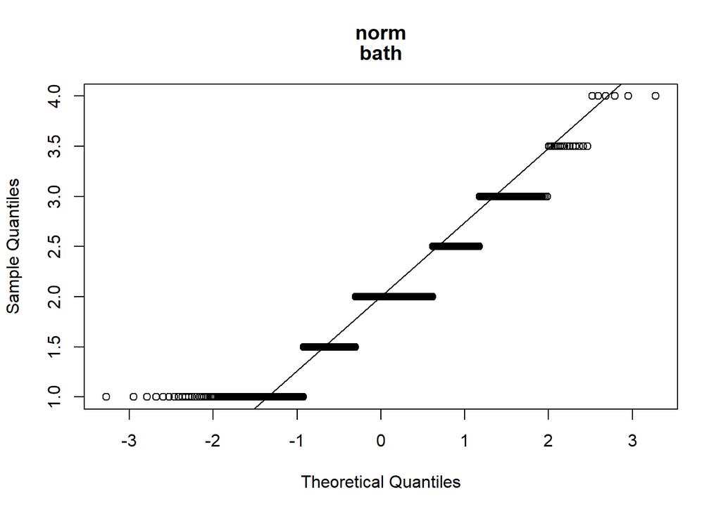

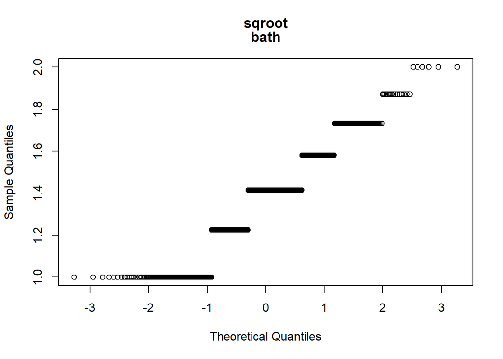

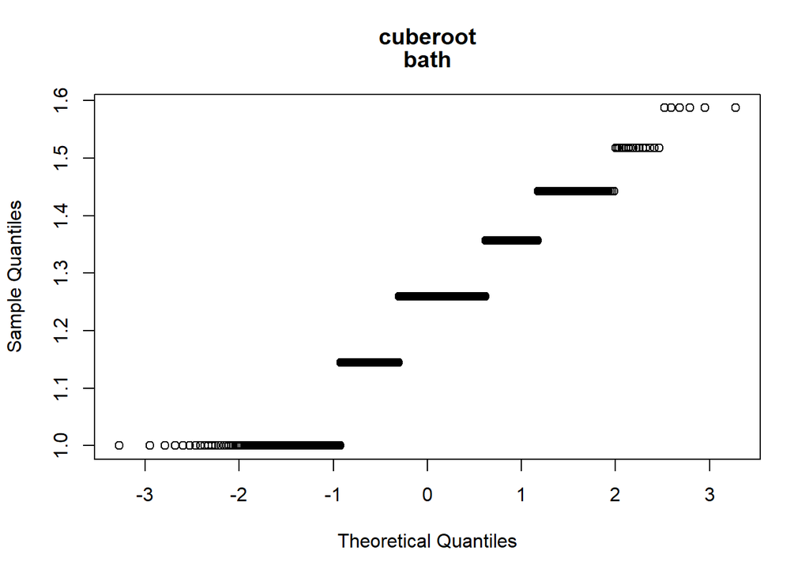

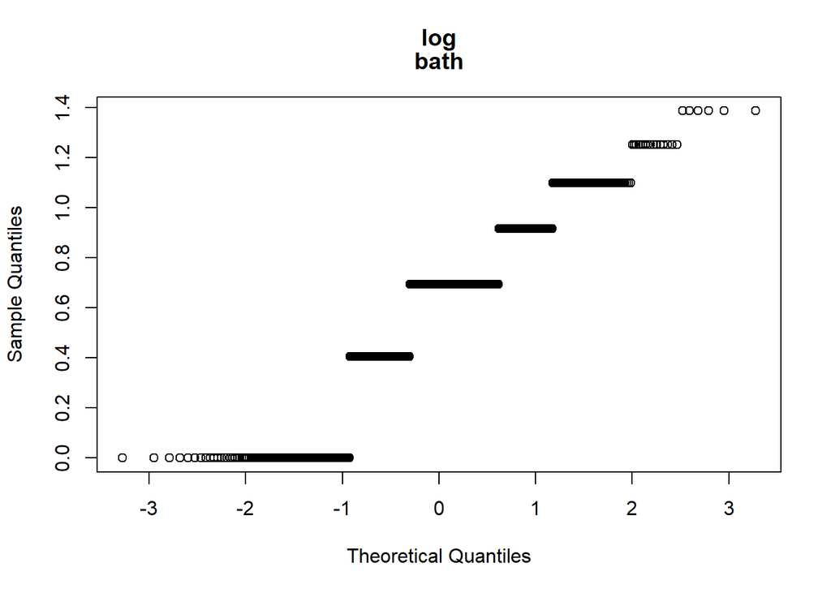

[47 more figures not shown]

```r
dt = as.data.frame(hd)
a = names(dt)

#we can check all most common transformations (log, cube- and squareroot) with a loop and print the qqplots to see if we can come close to a normal distribution with transformations

for (i in a) {
  qqnorm(dt[, i], main = c("norm",names(dt[i])))
  qqline(dt[, i], main = names(dt[i]))
  qqnorm((dt[, i])^(1/2), main = c("sqroot", names(dt[i])))
  qqnorm((dt[, i])^(1/3), main = c("cuberoot", names(dt[i])))
  ifelse(0 %in% dt[,i], print("no"),qqnorm(log(dt[, i]), main = c("log", names(dt[i]))))
}
```

```r
# Based on these plots I am going to apply the following transformations:
hd$s_p_log = log(hd$s_p)
hd$inv_log = log(hd$inv)
hd$ltsznew_log = log(hd$ltsznew)
hd$ratio_log= log(hd$ratio)

#additional variable
hd$bedbath = hd$bath/hd$bdrms
```

# Explanatory data Analysis

I am using linear regression here to find the most important independent variables that explain the house price best.

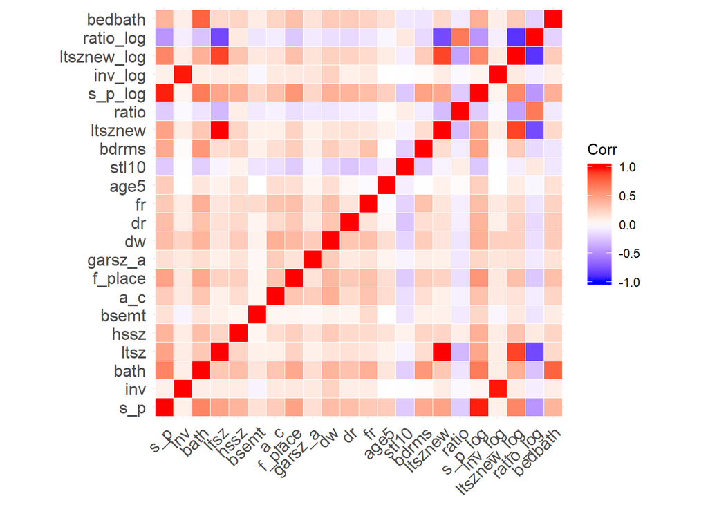

```r
#if(!require(devtools)) install.packages("devtools")
#devtools::install_github("kassambara/ggcorrplot")
library(ggcorrplot)
corr <- cor(hd)
ggcorrplot(corr, outline.col = "white")
```

```r
as.data.frame(colnames(hd))
```

```
##    colnames(hd)
## 1           s_p
## 2           inv
## 3          bath
## 4          ltsz
## 5          hssz
## 6         bsemt
## 7           a_c
## 8       f_place
## 9       garsz_a
## 10           dw
## 11           dr
## 12           fr
## 13         age5
## 14        stl10
## 15        bdrms
## 16      ltsznew
## 17        ratio
## 18      s_p_log
## 19      inv_log
## 20  ltsznew_log
## 21    ratio_log
## 22      bedbath
```

```r
# we cannot use some variables together

'
s_p
s_p_log     x
inv
bath              x
ltsz
hssz              x
bsemt             x
a_c               x
f_place       x
garsz_a       x
dw          x
dr                x
fr                x
age5              x
stl10             x
bdrms           x
ltsznew     x
ratio           x
inv_log
ltsznew_log x
ratio_log
bedbath     x


ratio_log shows multicorr so we use ratio instead as variable in the model
'
```

[output not shown]